# Toys Amazon Project

Kevin Yu

10/21/2019

## Discussion

Review ratings of a product not only can be an indicator for the perception of said product, they can also affect potential customers’ decision to whether make the purchase or not. As a result, ratings are a metrics every seller should pay attention to. In this Amazon Toys dataset of 10K observations, the rating of each product should be under the spotlight. Exploring this dataset and applying data modeling techniques, I was able to illustrate how the brand of a toy or the category a toy belongs to affects its ratings, and show that availability, number of reviews, price, and the sentiment expressed by the reviews all play a part in predicting the ratings of a product

## Data quality

This dataset comes in an untidy format. Namely, some variables need to be turned into numerics, many variables need to be separated into different variables, many non-content syntax need to be removed, two variables are identical, and a review sentiment variable needs to be added to perform sentiment analysis and model building. For a complete metadata of the cleaned datasets, see Appendix I.

#### Untidy data

There are several variables that are problematic and need to be addressed:

- **price** is not numeric and has currency symbol attached
- **number_available_in_stock** has both the number and the condition
- **average_review_rating** is a character variable that has “out of 5 stars” at the end of every entry
- **amazon_category_and_sub_category** puts all the categories and subcategories together
- **customers_who_bought_this_item_also_bought** is in url form and has several urls in single cells
- **items_customers_buy_after_viewing_this_item** is in url form and has several urls in single cells
- **customer_questions_and_answers** puts all pairs of questions and answers in single cells
- **customer_reviews** has all the reviews in single entries
- **sellers** has all the seller information in single entries

#### Missing values

Missing data is present throughout the dataset, but since the dataset has 10,000 observations, I do not anticipate missing values to present a serious problem.

#### Data completeness

The current collection of variables is adequate to perform most analysis. However, a review sentiment variable needs to be added to perform sentiment analysis and model building.

#### Other data issue

**description** and **product_description** have identical content, so one of the redundant variable should be removed.

## Data Cleaning

Pre-cleaned data was loaded for the analysis. In the process of data cleaning, I mainly used packages within `tidyverse`, for example, `readr` to import and export data, `dplyr` and `tidyr` to clean and tidy the dataset into tidy format, and `stringr` to manipulate string variables using regular expression. I also used the `lubridate` package to parse dates. Functions and loops were also used to write more efficient code. For sample code of data cleaning, please refer to the **Data Cleaning** section of Appendix II.

## Data Exploration to Better Understand Review Ratings

In this section, we are going to dive into the review ratings with several visualizations (using the `ggplot2`) to illustrate:

- What do the ratings look like
- Some factors that explains the ratings
- Sentiment analysis and how sentiment scores affect ratings

### Disecting Ratings

The distribution of the average ratings is extremely left-skewed:

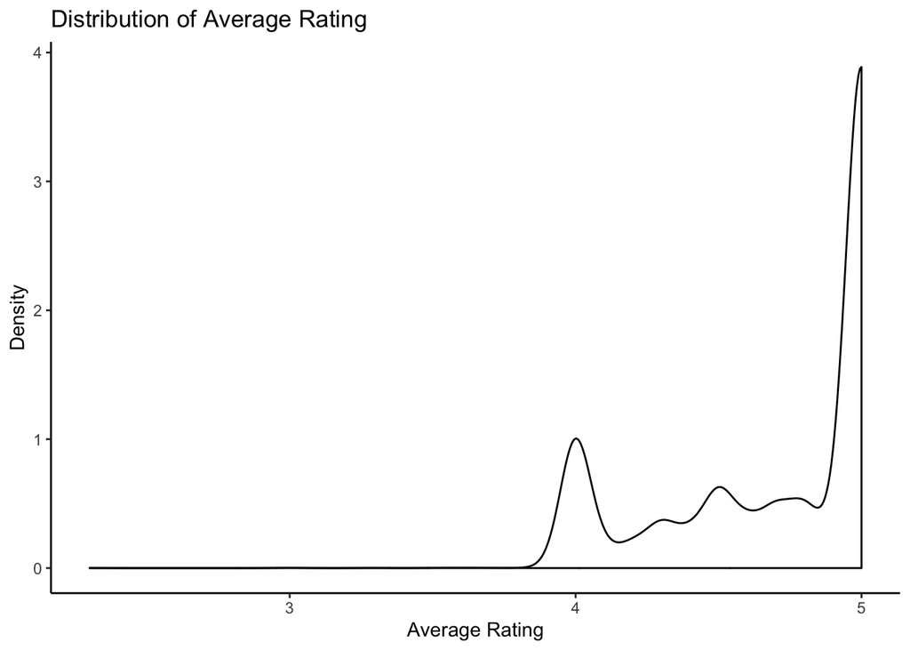

The majority of the products has a perfect 5-star ratings, and a lot gather around 4-star ratings. Some ratings distribute between 4 and 5 stars, but very few are below 4 stars. The ratings lack variability, which will present a major challenge in this study to explain what causes ratings to change.

One explaination of the lack of variability in ratings is the number of votes:

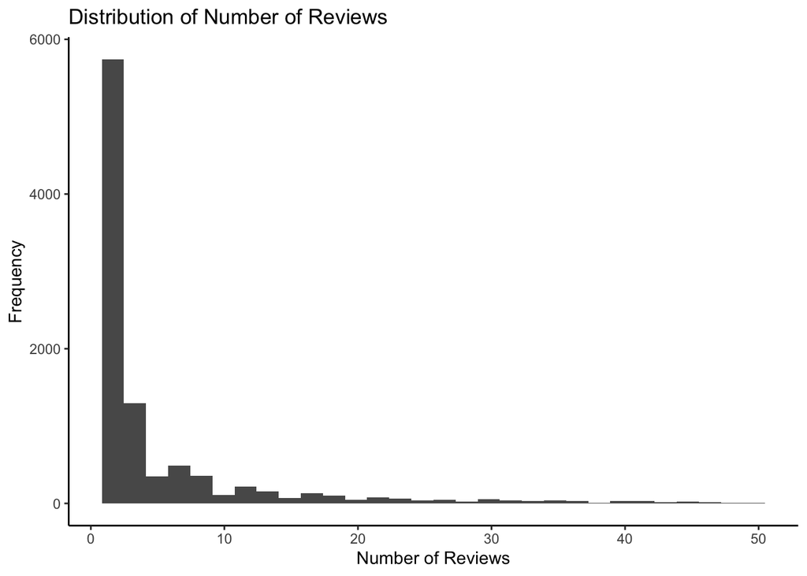

We can see that the majority of the products has very few reviews, which means a single review can largely determine the average rating. If the product has only one review, which is the case in this dataset, then the dense 5- or 4-star ratings can be explained.

### Categories and Brands

Categories and brands are two factors that can explain the review ratings. I found the most dominant categories and manufactures in this dataset can plotted how they correlate with ratings.

The top categories are hobbies, die-cast & toy vehicles, figures & playsets, etc.

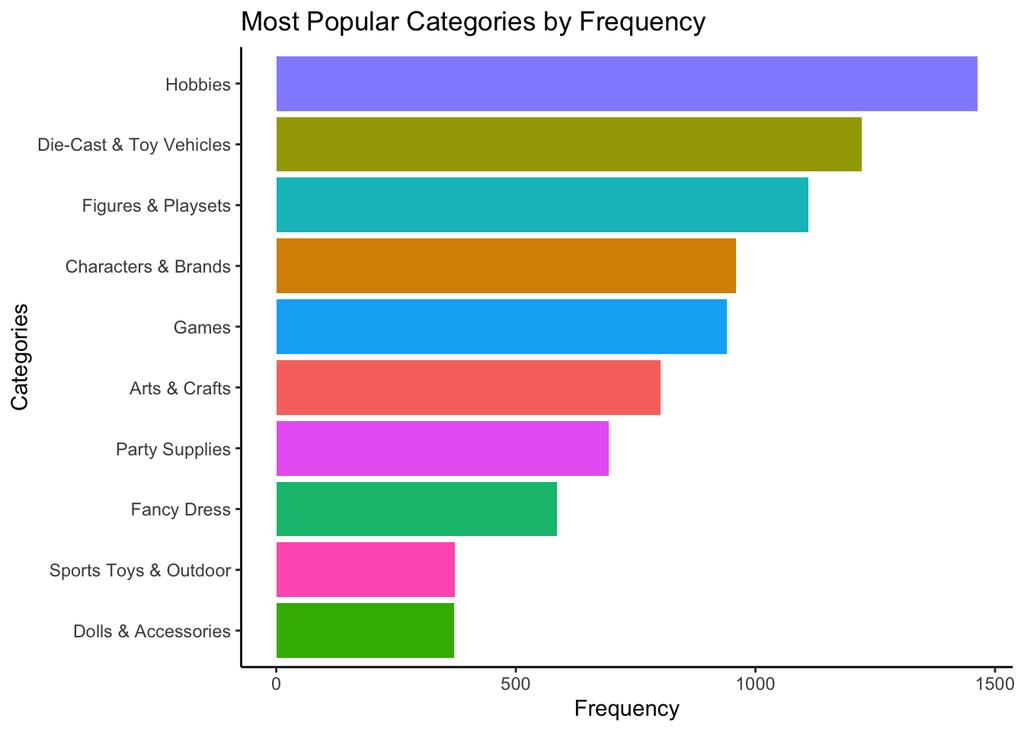

The most popular manufacturers are LEGO, Disney, Oxford Diecast, etc.

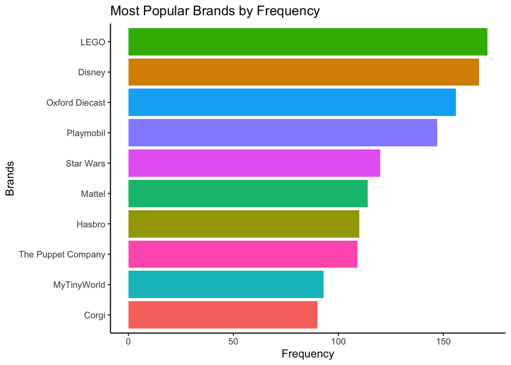

To find which categories are more likely be get good reviews, I need to filter out categories with too few products because Some categories have only one product and easily have the best avearge reviews. Then I plot the top 10 categories (n > 30) with the best average reviews.

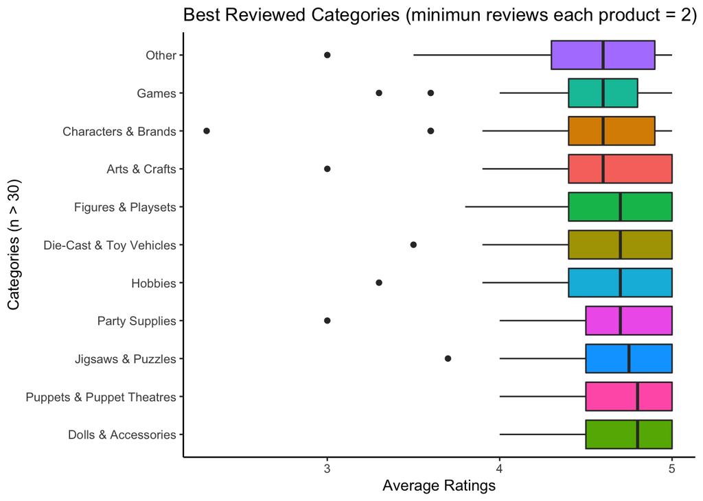

For n > 30, categories such as “Dolls & Accessories”, “Puppets & Puppet Theatres”, “Jigsaws & Puzzles” tend to get better reviews.

I use the same method to plot the top brands that has tend to get good reviews.

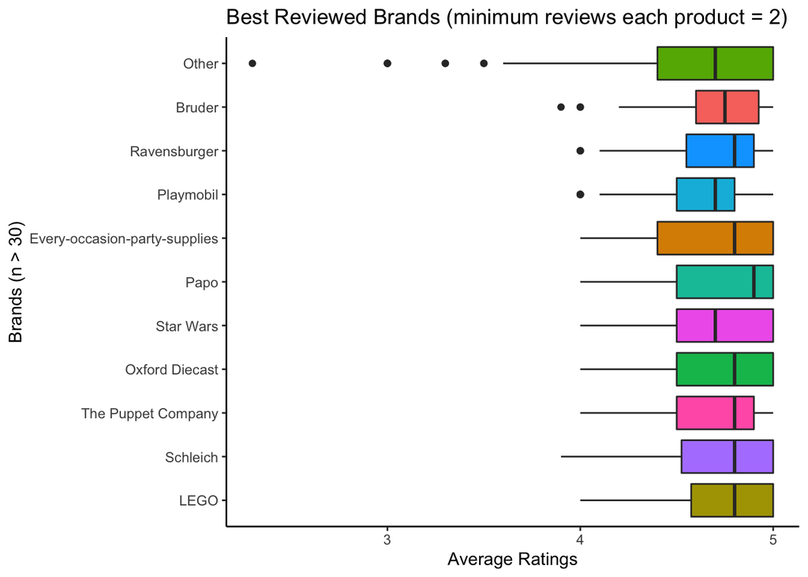

We can see that brands such as LEGO, Schleich, The Puppet Company tend to get good reviews.

### Sentiment Analysis

Another major factor to affect review ratings are the reviews themselves. If a customer expresses positive sentiment in their reviews, then they are more likely to leave a positive rating.

I used the `PerformanceAnalytics` and `tidytext` packages for this analysis.

An example of the first 10 products’ review sentiment is shown below:

```
## # A tibble: 8,503 x 2
##    uniq_id                          sentiment
##    <chr>                                <dbl>
##  1 0016eb63fa6c7a5e8930bc7732b13116     -0.5
##  2 00182f9b6081e58fea1fe76bc13eb022      1.8
##  3 0034d77b68130bba71aca6e733c7e1ac      2.5
##  4 0039295c7fcefba10d5fc333eff806d3      1.59
##  5 0046d3f852f55ee28b4a049ed387a946      2
##  6 00472dbbf1dc16092d18716f5dbc8f06      1
##  7 004c8d86fa377d80c1c52102562b8f13      2
##  8 0058ca8040260a2a4e185d12a62d2c6e     -3
##  9 005f14204fa56f34e37b84ce88e067db      3
## 10 0062979f8ad156917910fdac30031924      2
## # … with 8,493 more rows
```

The relationship between sentiment scores and average ratings are as follows:

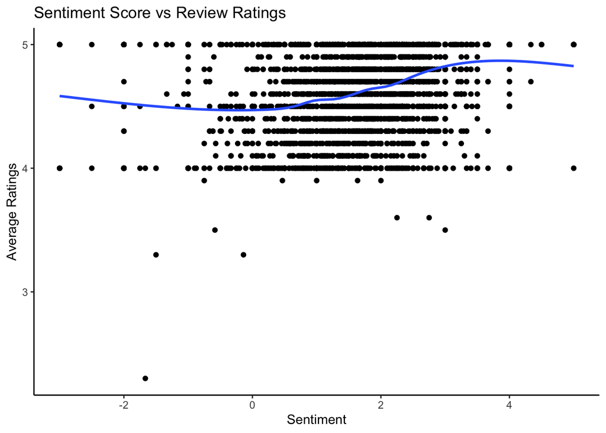

We can see that in general, more positive sentiment correlates with higher ratings, but extremely high or low sentiment may have the opposite effect. This may be due to the analysis’ inability to detect sarcasm. This suggests that a cubic term of the sentiment scores can be used to explain review ratings.

## Modeling the Ratings

Using the analysis above, I was able to build a linear model that can predict a product’s review ratings. This model has an explanatory power of 45%. The result of the model is shown below:

```
##        r2     adjr2
## 0.4541827 0.2158018
```

## Appendix I: Metadata

#### Product

- **uniq_id** (char): the unique identifier of each product
- **product_name** (char): name of the product
- **manufacturer** (char): name of the manufacturer
- **price** (num): price of the product in British Pounds
- **number_available** (int): the available stock of the product
- **condition** (char): the condition of the product, new or used
- **number_of_reviews** (int): number of reviews of the product
- **number_of_answered_questions** (int): number of answered questions of the product
- **average_review_rating** (num): the average rating out of 5 stars
- **discription** (char) and **product_information** (char): description and technical details about the product

#### Category

- **uniq_id** (char): the unique identifier of each product
- **category** (char): the category of the product
- **sub_cat1-4** (char): the sub categories of the product

#### Also Bought

- **uniq_id** (char): the unique identifier of each product
- **also_bought_key** (char): together with uniq_id to uniquely identify an also_bought product
- **also_bought_product** (char): product customers also bought with each product

#### Bought after Viewing

- **uniq_id** (char): the unique identifier of each product
- **bought_after_key** (char): together with uniq_id to uniquely identify an bought_after product
- **bought_after_product** (char): product customers bought after viewing each product

#### Question and Answer

- **uniq_id** (char): the unique identifier of each product
- **question** (char): question of each product
- **answer** (char): answer to the question

## Appendix II: Sample Code

### Data Cleaning

This section includes samples of the code I wrote to clean the original dataset. I mainly used packages within `tidyverse`, for example, `readr` to import and export data, `dplyr` and `tidyr` to reshape the dataset into clean format, and `stringr` to manipulate string variables using regular expression. I also used the `lubridate` package to parse dates. Functions and loops were also used to write more efficient code.

In a major overhaul from the previous work I’ve done on the cleaning of this dataset, I split the dataset into 7 dataframes first, before I started to clean the data. I defined a function to clean the amazon urls, a major improvement of code efficiency over my previous work. I reduced the use of loops this time in data cleaning, because loops are less efficient and take longer to run; instead, I focused on cleaning string data cells first before separating them into different columns, removing the need to loop. At last, I focused more on using regular expression and the “look around” expressions this time around.

I used the `readr` package to read the data and specify column type:

```r
Toys_Amazon <- read_csv("Toys_Amazon.csv",
                        # specify data type as numeric to avoid parsing error
                        col_types = cols(number_of_reviews = col_number()))
```

I used the `dplyr` package to split the data into 7 dataframes:

```r
product <- Toys_Amazon %>%
  select(uniq_id, product_name, manufacturer, price,
         number_available_in_stock, number_of_reviews,
         number_of_answered_questions, average_review_rating,
         description, product_information, product_description)

cat <- Toys_Amazon %>%
  select(uniq_id, amazon_category_and_sub_category)

also_bought <- Toys_Amazon %>%
  select(uniq_id, customers_who_bought_this_item_also_bought)

bought_after <- Toys_Amazon %>%
  select(uniq_id, items_customers_buy_after_viewing_this_item)

qa <- Toys_Amazon %>%
  select(uniq_id, customer_questions_and_answers)

reviews <- Toys_Amazon %>%
  select(uniq_id, customer_reviews)

sellers <- Toys_Amazon %>%
  select(uniq_id, sellers)
```

Multiple techniques were used to clean the `product` dataframe. To demonstrate, I used the `mutate()` function in the `dplyr` package to transform the `price` variable into numbers:

```r
df1 <- product %>%
  # parse price as numeric
  mutate(price = parse_number(price))
```

or the `separate()` function in the `tidyr` package to separate number available into availability and condition:

```r
df2 <- df1 %>%
  # separate into availability and condition
  separate(number_available_in_stock,
           into = c("number_available", "condition")) %>%
  # parse availability as numeric
  mutate(number_available = parse_number(number_available))
```

or regular expression to remove the " out of 5 stars" in the `average_review_rating` variable and keep only the rating numbers:

```r
df3 <- df2 %>%
  mutate(
    average_review_rating =
      # parse as number
      parse_number(
        # extract the ratings
        str_extract(
          average_review_rating,
          # use regular expression to
          # look for the ratings
          "[:digit:]\\.[:digit:](?=[:space:])"
        )
      )
  )
```

I also investigated the similarity between the `description` and `product_description` variables with the `ifelse()` function in the base R package and the `filter()` function in the `dplyr` package, and discovered that they are identical:

```r
tmp <- df3

# create variable that returns 1
# when description is different from
# product_description
tmp$isdiff <- ifelse(tmp$description ==
                       tmp$product_description,
                     0, 1)

# output the observations that are different
tmp <- tmp %>%
  select(description, product_description) %>%
  filter(tmp$isdiff == 1)
```

Variables `customers_who_bought_this_item_also_bought` and `items_customers_buy_after_viewing_this_item` are very similar: they are both a collection of amazon urls associated with each observation. To reduce the redundancy of my code, I wrote a function to clean these urls and applied it to the two variables.

```r
clean_amzn_url <- function(data, col, into, n) {

  tmp <- data

  # clean urls into product names
  tmp[[col]] <-
    tmp[[col]] %>%
    # remove head of urls
    str_remove_all("http://www.amazon.co.uk/") %>%
    # replace dashes with spaces
    str_replace_all("\\-", " ") %>%
    # remove tail of urls
    str_remove_all("(?<=\\/dp\\/)[:alnum:]*(?=[:space:]\\|[:space:])") %>%
    # remove tail of the last url in a cell
    str_remove("(?<=\\/dp\\/)[:alnum:]*(?![:blank:])") %>%
    # remove the remnant of urls
    str_remove_all("\\/dp\\/")

  tmp <- tmp %>%
    # separate each product into a new column
    separate(col,
             into = c(paste0(into, 1:n)),
             sep = " \\| ") %>%
    # gather new columns into clean format
    pivot_longer(c(paste0(into, 1:n)),
                 names_to = paste0(into, "_key"),
                 values_to = paste0(into, "_product")) %>%
    # drop na rows
    drop_na()

  return(tmp)

}

# use the function to clean also_bought dataframe
also_bought <- also_bought %>%
  clean_amzn_url(col = "customers_who_bought_this_item_also_bought",
                 into = "also_bought",
                 # max of 12 also_bought products
                 n = 12)

# use the function to clean bought_after_viewing dataframe
bought_after <- bought_after %>%
  clean_amzn_url(col = "items_customers_buy_after_viewing_this_item",
                 into = "bought_after_viewing",
                 # max of 4 bought_after_viewing products
                 n = 4)
```

I used the `pivot_longer()` function (formerly the `gather()` function) in the `tidyr` package a lot to gather the data into clean format. To demonstrate, below is my code, which includes the use of `pivot_longer()` to clean the `qa` dataframe:

```r
df1 <- qa %>%
  # separate into 10 qa sets
  separate(customer_questions_and_answers,
           into = c(paste0("question_set", 1:10)),
           sep = " \\| ")

df2 <- df1 %>%
  # gather qa sets into clean format
  pivot_longer(c(paste0("question_set", 1:10)),
               names_to = "question_sets",
               values_to = "question_answer") %>%
  # drop na columns
  drop_na()

df3 <- df2 %>%
  # separate each qa set into question & answer
  separate("question_answer",
           into = c("question", "answer"),
           sep = " // ")
```

Loops are also used in the process of data cleaning. One example is then I loop over the `reviews` dataframe to replace empty `reviewer_credential` variable cells with `NA`s:

```r
for (i in 1:nrow(df1)) {
  df1[i, "reviewer_credential"] <-
    ifelse(df1[i, "reviewer_credential"] != "",
           df1[i, "reviewer_credential"],
           NA)
}
```

A combination of the above functions and techniques was also used to clean the `cat`, `also_bought`, `bought_after`, and `sellers` dataframes.

At last, I used the `write_csv()` function to export the 7 clean dataframes into `.csv` files.

```r
write_csv(also_bought, "also_bought.csv")
write_csv(bought_after, "bought_after.csv")
write_csv(cat, "category.csv")
write_csv(product, "product.csv")
write_csv(qa, "question_answer.csv")
write_csv(reviews, "reviews.csv")
write_csv(sellers, "sellers.csv")
```

### Data Visualization

I used the `ggplot2` package to visualize data. A good example of the code is the bar chart I plotted for the top 10 manufacturers, where I filter the dataset with only the top 10 brands, reorder the chart in decending order, fill each brand with a different color to be more visually pleasing, and applied a simplistic theme and appropiete labels to draw a clear graph:

```r
brand_plot <- ggplot(data = filter(brand, manufacturer %in% topbrandv)) +
  geom_bar(aes(x = reorder(manufacturer, n),
               y = n,
               fill = topbrandv),
           stat = "identity") +
  labs(title = "Most Popular Brands by Frequency",
       x = "Brands",
       y = "Frequency") +
  coord_flip() +
  theme_classic() +
  theme(legend.position = "none")
brand_plot
```

### Sentiment Analysis

```r
# unnest words
review_words <- reviews %>%
  select(uniq_id, review) %>%
  unnest_tokens(word, review) %>%
  filter(!word %in% stop_words$word,
         str_detect(word, "^[a-z']+$"))

# get afinn scores for words
AFINN <- get_sentiments("afinn")

# take the average sentiment score of each product
review_sentiments <- review_words %>%
  inner_join(AFINN, by = "word") %>%
  group_by(uniq_id) %>%
  summarise(sentiment = mean(value))
```

### Linear Modeling

I used the `lm()` function in the base R package to build linear models.

```r
mod <- lm(average_review_rating ~ number_available + log(number_of_reviews) +
           log(price) + sentiment + I(sentiment^2) + I(sentiment^3) + category +
           manufacturer,
           data = reg)

r2 <- summary(mod)$r.squared
adjr2 <- summary(mod)$adj.r.squared
```

I also performed anova analysis to evaluate the significance of variables:

```r
mod6 <- lm(average_review_rating ~ number_available + log(number_of_reviews) +
           log(price) + sentiment + I(sentiment^2) + I(sentiment^3) + category,
           data = reg)

mod7 <- lm(average_review_rating ~ number_available + log(number_of_reviews) +
           log(price) + sentiment + I(sentiment^2) + I(sentiment^3) + category +
           manufacturer,
           data = reg)

anova(mod7, mod6)
```